# STT 5811 Lab02: Explanatory Data Analysis

SOLUTIONS

Friday, February 06, 2026 @ 10:12 PM

# Instructions

This data lab is adapted from the [**Intro to R - Flight Delays**](https://openintrostat.github.io/oilabs-tidy/02_intro_to_data/intro_to_data.html) lab in [**Section 6.3**](https://openintro-ims.netlify.app/explore-applications#sec-explore-labs) of the IMS2E textbook. Skim the textbook lab (skip the video), then complete your analysis here. For all plots, add a title and descriptive axis labels using `labs()`. You may make other useful customizations to your plots. Use complete sentences when answering questions.

# Packages Used

Load the `tidyverse` and `openintro` packages.

```r
library(tidyverse)
library(openintro)
```

# `nycflights` Dataset

## Dataset Description

The dataset is a random sample of flights that departed from one of three big New York City (NYC) area airports (JFK, LGA or EWR) in 2013. It was taken from a larger dataset of all 336,776 flights that departed in 2013, found in the `nycflights13` package. Each observation is one flight.

## Explore the Dataset

Assign the `nycflights` dataset to an object in your Environment.

```r
flightdata <- nycflights
```

Use `names()` to view the variable names.

```r
names(flightdata)
```

```
 [1] "year"      "month"     "day"       "dep_time"  "dep_delay" "arr_time"
 [7] "arr_delay" "carrier"   "tailnum"   "flight"    "origin"    "dest"
[13] "air_time"  "distance"  "hour"      "minute"
```

Variable definitions are important for understanding data. View the dataset’s codebook by entering `?nycflights` in the Console, or search in the Help tab of the Files pane using the dataset’s name. Briefly define each variable in the dataset, including the units of measure for all numerical variables. Search online for the airport names that correspond to the U.S. airport codes JFK, LGA and EWR. Your definitions do not need to be complete sentences.

Create a new variable that identifies departures as “on-time” or “delayed,” where any flight delayed less than five minutes is considered “on-time.” Create a similar variable for arrivals, where “on time” is any flight that was less than five minutes late. Also make a variable that represents the average speed traveled by the plane for each flight, in miles per hour (mph).

```r
flightdata <- flightdata |>
  mutate(
    dep_type = ifelse(dep_delay < 5, "on-time", "delayed"),
    arr_type = ifelse(arr_delay < 5, "on-time", "delayed"),
    avg_speed = distance/(air_time/60)
  )
```

Use `glimpse()` to explore the dataset and verify your new variables.

```r
glimpse(flightdata)
```

```
Rows: 32,735
Columns: 19
$ year      <int> 2013, 2013, 2013, 2013, 2013, 2013, 2013, 2013, 2013, 2013, …
$ month     <int> 6, 5, 12, 5, 7, 1, 12, 8, 9, 4, 6, 11, 4, 3, 10, 1, 2, 8, 10…
$ day       <int> 30, 7, 8, 14, 21, 1, 9, 13, 26, 30, 17, 22, 26, 25, 21, 23, …
$ dep_time  <int> 940, 1657, 859, 1841, 1102, 1817, 1259, 1920, 725, 1323, 940…
$ dep_delay <dbl> 15, -3, -1, -4, -3, -3, 14, 85, -10, 62, 5, 5, -2, 115, -4, …
$ arr_time  <int> 1216, 2104, 1238, 2122, 1230, 2008, 1617, 2032, 1027, 1549, …
$ arr_delay <dbl> -4, 10, 11, -34, -8, 3, 22, 71, -8, 60, -4, -2, 22, 91, -6, …
$ carrier   <chr> "VX", "DL", "DL", "DL", "9E", "AA", "WN", "B6", "AA", "EV", …
$ tailnum   <chr> "N626VA", "N3760C", "N712TW", "N914DL", "N823AY", "N3AXAA", …
$ flight    <int> 407, 329, 422, 2391, 3652, 353, 1428, 1407, 2279, 4162, 20, …
$ origin    <chr> "JFK", "JFK", "JFK", "JFK", "LGA", "LGA", "EWR", "JFK", "LGA…
$ dest      <chr> "LAX", "SJU", "LAX", "TPA", "ORF", "ORD", "HOU", "IAD", "MIA…
$ air_time  <dbl> 313, 216, 376, 135, 50, 138, 240, 48, 148, 110, 50, 161, 87,…
$ distance  <dbl> 2475, 1598, 2475, 1005, 296, 733, 1411, 228, 1096, 820, 264,…
$ hour      <dbl> 9, 16, 8, 18, 11, 18, 12, 19, 7, 13, 9, 13, 8, 20, 12, 20, 6…
$ minute    <dbl> 40, 57, 59, 41, 2, 17, 59, 20, 25, 23, 40, 20, 9, 54, 17, 24…
$ dep_type  <chr> "delayed", "on-time", "on-time", "on-time", "on-time", "on-t…
$ arr_type  <chr> "on-time", "delayed", "delayed", "on-time", "on-time", "on-t…
$ avg_speed <dbl> 474.4409, 443.8889, 394.9468, 446.6667, 355.2000, 318.6957, …
```

# Categorical Analysis

## Departure Airports

Create a table to show how many flights departed from each airport. Include counts and proportions.

```r
flightdata |>
  count(origin) |>
  mutate(prop = prop.table(n)) |>
  knitr::kable()
```

| origin | n | prop |
| --- | --- | --- |
| EWR | 11771 | 0.3595845 |
| JFK | 10897 | 0.3328853 |
| LGA | 10067 | 0.3075302 |

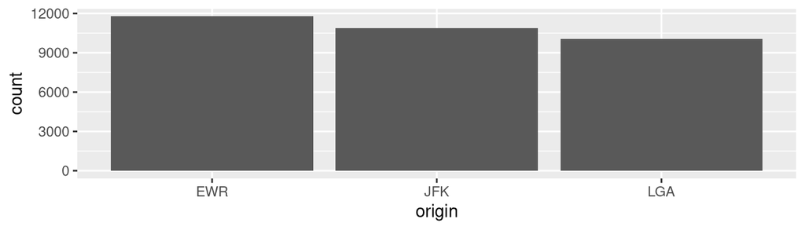

```r
ggplot(flightdata, aes(x = origin)) +
  geom_bar()
```

## Destination Airports

Use the `n_distinct()` function to find how many different destination airports the data contain.

```r
# Option 1
n_distinct(flightdata$dest)
```

```
[1] 102
```

```r
# Option 2
flightdata |>
  pull(dest) |>
  n_distinct()
```

```
[1] 102
```

Make a table to show the top five destinations for departing flights. Include counts and proportions. Save the result as an object in your Environment, but be sure to display it here as well.

```r
top5dest <- flightdata |>
  count(dest) |>
  mutate(prop = prop.table(n)) |>
  slice_max(n, n = 5)
top5dest
```

| dest | n | prop |
| --- | --- | --- |
| ATL | 1653 | 0.05049641 |
| ORD | 1588 | 0.04851077 |
| LAX | 1583 | 0.04835803 |
| BOS | 1470 | 0.04490606 |
| CLT | 1383 | 0.04224836 |

Use your saved table and the `geom_col()` function to create a barplot for the top five destinations. Use `reorder()` in the plot aesthetics to sort the bars from largest to smallest.

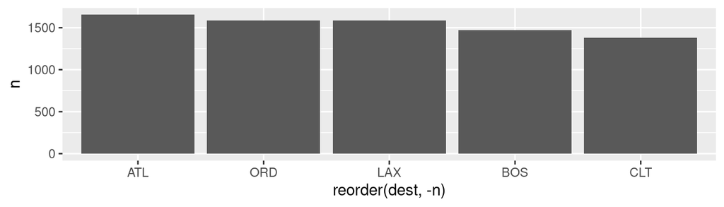

```r
ggplot(top5dest, aes(x = reorder(dest, -n), y = n)) +
  geom_col()
```

Make a table to show the top three destinations grouped by airport. Include counts and proportions. Save the result as an object in your Environment, but be sure to display it here as well.

```r
top3dest <- flightdata |>
  group_by(origin) |>
  count(dest) |>
  mutate(prop = prop.table(n)) |>
  slice_max(n, n = 3)
top3dest
```

| origin | dest | n | prop |
| --- | --- | --- | --- |
| EWR | ORD | 601 | 0.05105768 |
| EWR | SFO | 513 | 0.04358168 |
| EWR | ATL | 512 | 0.04349673 |
| JFK | LAX | 1115 | 0.10232174 |
| JFK | SFO | 832 | 0.07635129 |
| JFK | BOS | 585 | 0.05368450 |
| LGA | ATL | 946 | 0.09397040 |
| LGA | ORD | 801 | 0.07956690 |
| LGA | CLT | 583 | 0.05791199 |

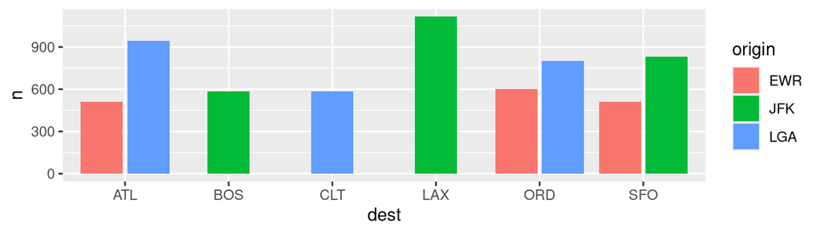

```r
ggplot(top3dest, aes(x = dest, y = n, fill = origin)) +
  geom_col(position = position_dodge2(preserve = "single"))
```

## Analysis Discussion 1

1. How do total flight departures compare across the three airports? Discuss this as if I cannot see your table or plot (e.g., cite relevant summary statistics).

2. What are the top five flight destinations? What fraction of flights do they represent overall? Does this set of destinations make sense to you? Discuss.

3. Discuss similarities and differences between the top three destinations for each airport, and make relevant comparisons to the top five overall airports.

# Numerical Analysis

## Departure Delays

Filter the dataset to extract only those flights going to the most common destination (overall) . Use this extracted set of flights for all analyses involving delays.

```r
flightdataATL <- flightdata |>
  filter(dest == "ATL")
```

Make a histogram and boxplot to visualize the distribution of departure delays and identify outliers. Use 120 bins for your histogram.

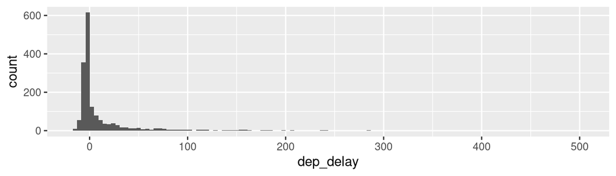

```r
ggplot(flightdataATL, aes(x = dep_delay)) +
  geom_histogram(bins = 120)
```

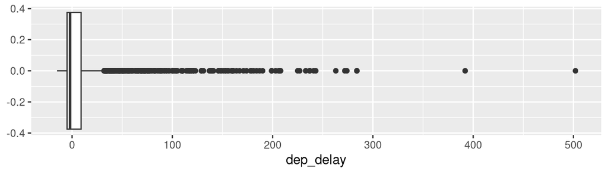

```r
ggplot(flightdataATL, aes(x = dep_delay)) +
  geom_boxplot()
```

Calculate the mean and median departure delay, as well as the standard deviation, IQR, and upper and lower fences used to identify outliers in the boxplot.

```r
flightdataATL |>
  summarize(
    mean_dd = mean(dep_delay),
    median_dd = median(dep_delay),
    sd_dd = sd(dep_delay),
    iqr_dd = IQR(dep_delay),
    lf_dd = fivenum(dep_delay)[2] - iqr_dd,
    uf_dd = fivenum(dep_delay)[4] + iqr_dd
  )
```

| mean_dd | median_dd | sd_dd | iqr_dd | lf_dd | uf_dd |
| --- | --- | --- | --- | --- | --- |
| 12.97459 | -2 | 41.80403 | 14 | -19 | 23 |

Calculate the same statistics, along with the number of flights, grouped by the origin airport.

```r
flightdataATL |>
  group_by(origin) %>%
  summarize(
    n_origin = n(),
    mean_dd = mean(dep_delay),
    median_dd = median(dep_delay),
    sd_dd = sd(dep_delay),
    iqr_dd = IQR(dep_delay),
    lf_dd = fivenum(dep_delay)[2] - iqr_dd,
    uf_dd = fivenum(dep_delay)[4] + iqr_dd
  )
```

| origin | n_origin | mean_dd | median_dd | sd_dd | iqr_dd | lf_dd | uf_dd |
| --- | --- | --- | --- | --- | --- | --- | --- |
| EWR | 512 | 16.572266 | -1 | 47.19554 | 21 | -25 | 38 |
| JFK | 195 | 8.589744 | -1 | 27.05980 | 10 | -13 | 17 |
| LGA | 946 | 11.931290 | -2 | 41.08742 | 11 | -16 | 17 |

Find the on-time departure rates for the three origin airports. Arrange them from best to worst.

```r
flightdataATL |>
  group_by(origin) |>
  summarise(ot_dep_rate = sum(dep_type == "on-time") / n()) |>
  arrange(desc(ot_dep_rate))
```

| origin | ot_dep_rate |
| --- | --- |
| LGA | 0.7219873 |
| JFK | 0.7025641 |
| EWR | 0.6621094 |

## Departure vs. Arrival Delays

Plot arrival delays (y) versus departure delays (x). Add a line showing y = x using `geom_abline()`. Use `coord_fixed()` so that the x- and y-axis units have the same scaling.

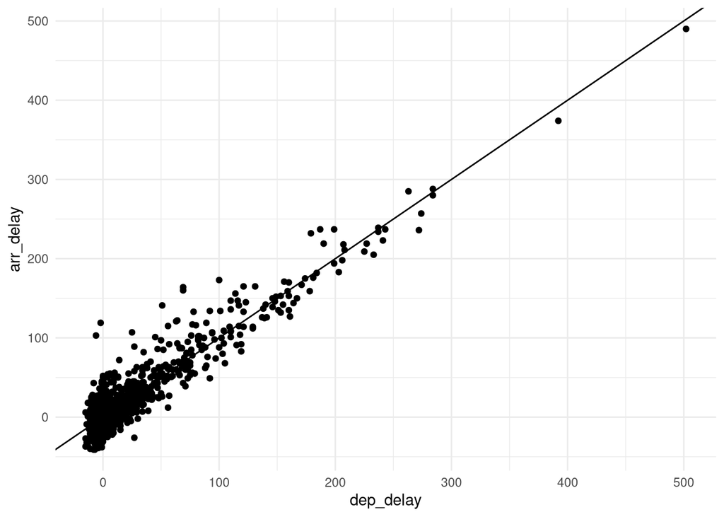

```r
flightdataATL |>
  ggplot(aes(x = dep_delay, y = arr_delay)) +
  geom_point() +
  geom_abline(slope = 1, intercept = 0) +
  theme_minimal()
```

Plot arrival delays (y) versus departure delays (x) for flights that arrived on-time. Color the points by whether or not the departure was delayed. Use `alpha` to better visualize overlapping points.

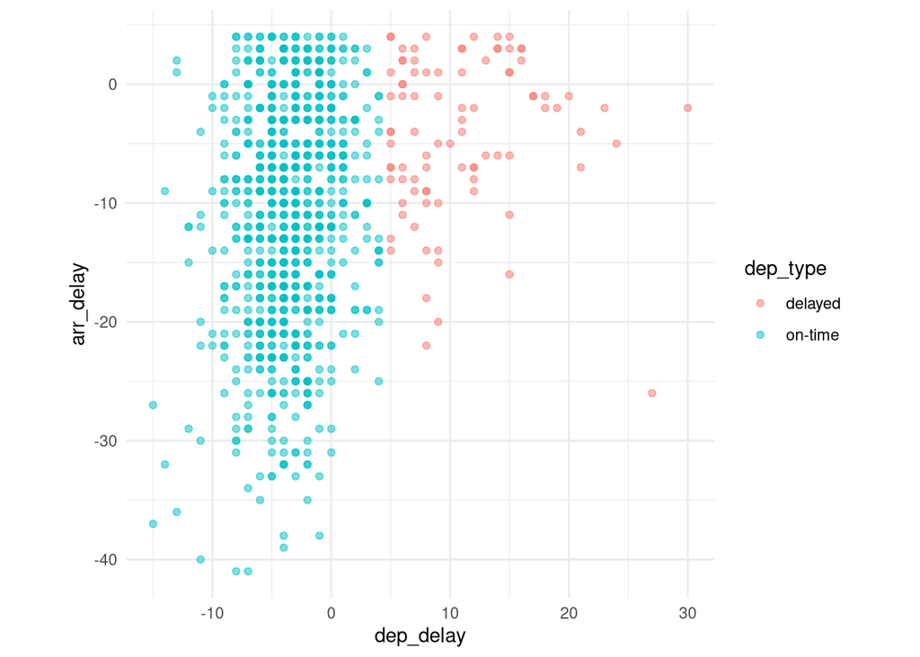

```r
flightdataATL |>
  filter(arr_type == "on-time") |>
  ggplot(aes(x = dep_delay, y = arr_delay, color = dep_type)) +
  geom_point(alpha = 0.5) +
  coord_fixed() +
  theme_minimal()
```

## Flight Speed vs. Distance

Make a scatterplot of speed (y) versus distance (x) for the full dataset. Color by departure type.

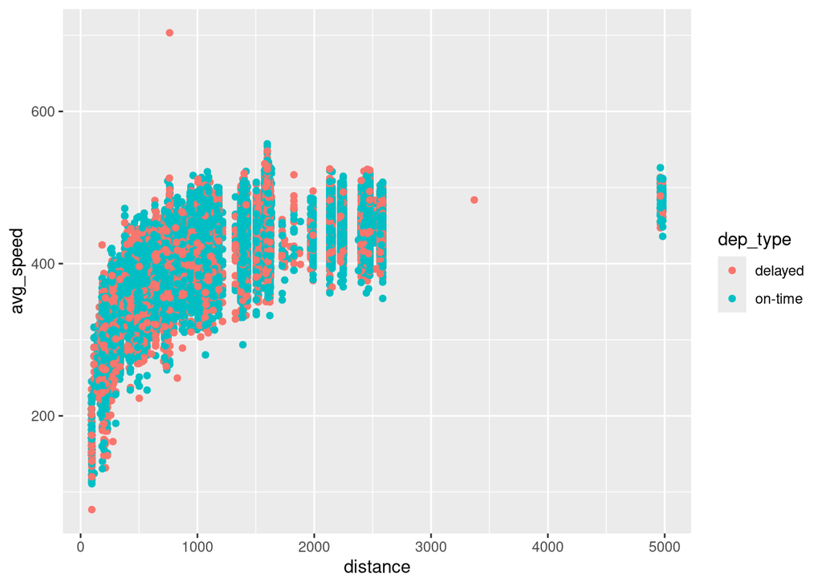

```r
ggplot(flightdata, aes(x = distance, y = avg_speed, color = dep_type)) +
  geom_point()
```

## Analysis Discussion 2

1. How do total flight departures compare across the three airports? Discuss this as if I cannot see your table or plot (e.g., cite relevant summary statistics).